# Derenda_Kamil_2_projekt1

Kamil Derenda

2024-11-17

DBSCAN vs HDBSCAN

```r
library(sf)
library(dbscan)
```

Wczytywanie danych

```r
points <- st_read("C:\\Users\\kamil\\Desktop\\3rok\\5sem\\Analiza_Danych_Przestrzennych\\cw5\\zestaw2_XYTableToPoi_ProjectX.shp")
osiedle <- st_read("C:\\Users\\kamil\\Desktop\\3rok\\5sem\\Analiza_Danych_Przestrzennych\\cw5\\osiedla.shp")
```

Wyodrębnienie współrzędnych z punktów

```r
points_coords <- st_coordinates(points)
```

Mapa Krakowa wraz z punktami oznaczającymi miejsca przestępstw.

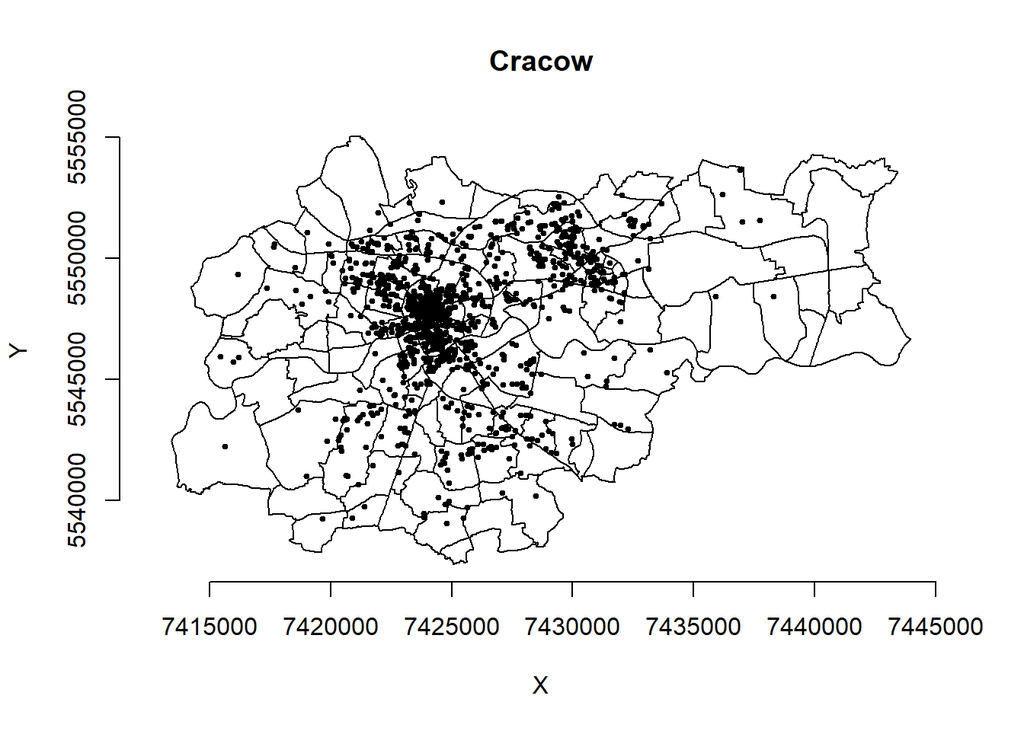

```r
plot(osiedle$geometry, xlab='X', ylab="Y")
plot(points$geometry, add=TRUE, pch=19, cex=0.5)
title("Cracow")
axis(1)
axis(2)
```

Dobór promienia zostanie dobrany na takiej zasadzie, aby średnio każdy punkt rdzenia zawierał minPts punktów, czyli najmniejszą wymaganą liczbę punktów do utworzenia klastra. Zastosuję w tym przypadku funkcję knndist.

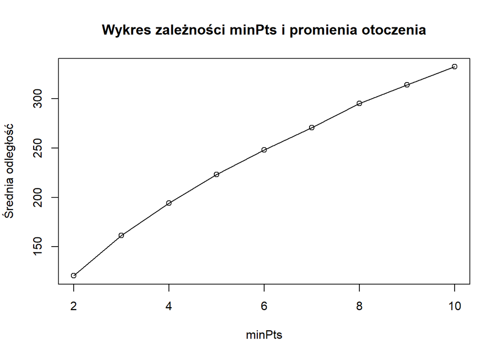

```r
minPts_values <- 2:10
distances <- numeric(length(minPts_values))
for (i in 1:length(minPts_values)) {
  minPts <- minPts_values[i]
  knn_dist <- kNNdist(points_coords, k = minPts)
  distances[i] <- mean(knn_dist)
}

plot(
  minPts_values,
  distances,
  type = "o",
  xlab = "minPts",
  ylab = "Średnia odległość",
  main = "Wykres zależności minPts i promienia otoczenia"
)
```

Po sczytaniu z wykresu odległości dla 4, 6 oraz 10 punktów dokonuję analizy klastrów za pomocą funkcji dbscan.

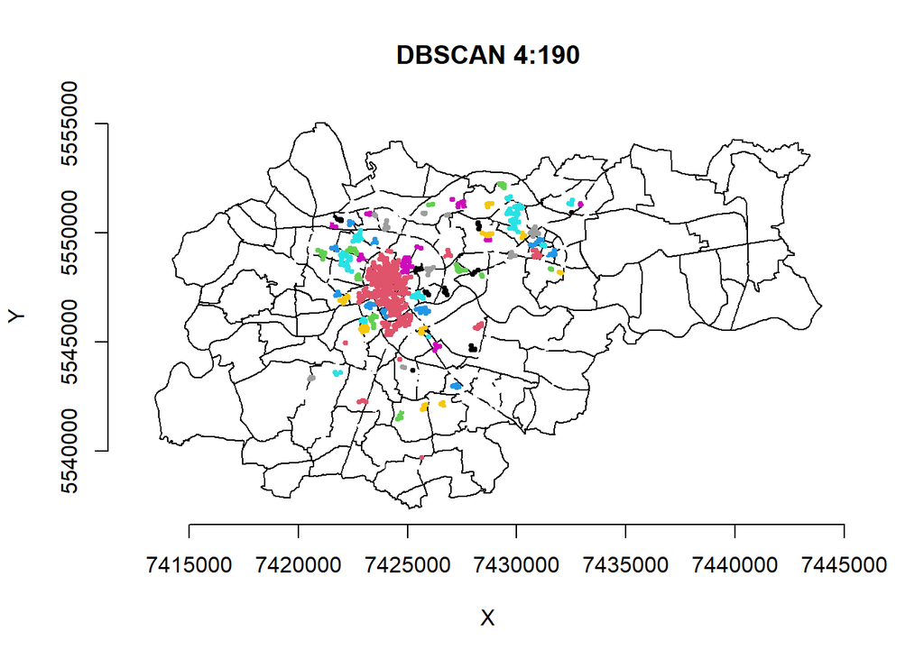

```r
db <- dbscan(points_coords, eps = 190, minPts = 4)
plot(osiedle$geometry, xlab = 'X', ylab = "Y", main = "DBSCAN 4:190")
plot(points$geometry, add = TRUE, pch = 19, cex = 0.5, col = ifelse(db$cluster == 0, 0, db$cluster + 1))
axis(1)
axis(2)
```

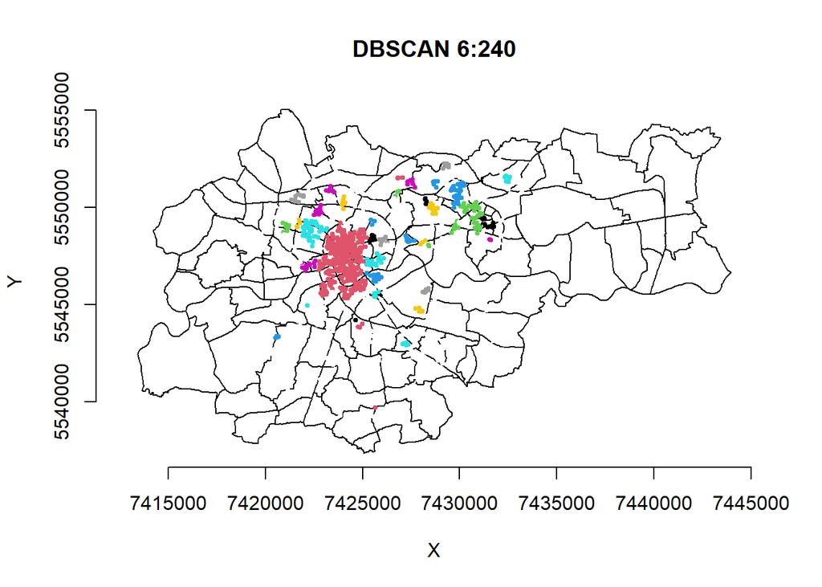

```r
db <- dbscan(points_coords, eps = 240, minPts = 6)
plot(osiedle$geometry, xlab = 'X', ylab = "Y", main = "DBSCAN 6:240")
plot(points$geometry, add = TRUE, pch = 19, cex = 0.5, col = ifelse(db$cluster == 0, 0, db$cluster + 1))
axis(1)
axis(2)
```

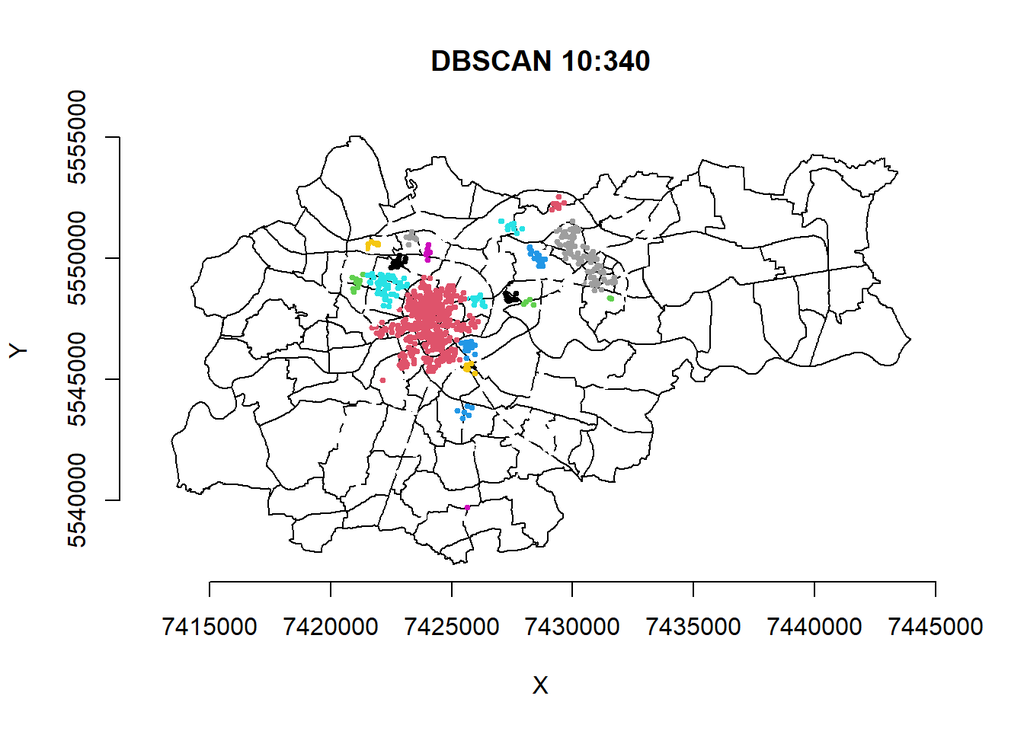

```r
db <- dbscan(points_coords, eps = 340, minPts = 10)
plot(osiedle$geometry, xlab = 'X', ylab = "Y", main = "DBSCAN 10:340")
plot(points$geometry, add = TRUE, pch = 19, cex = 0.5, col = ifelse(db$cluster == 0, 0, db$cluster + 1))
axis(1)
axis(2)
```

Jak można zauważyć, wraz ze wzrostem ilości minimalnej liczby punktów, oraz odległości mniejsze klastry są traktowane jako szum, lub wchłaniane przez większe klastry znajdujące sie w zadanej odległości.

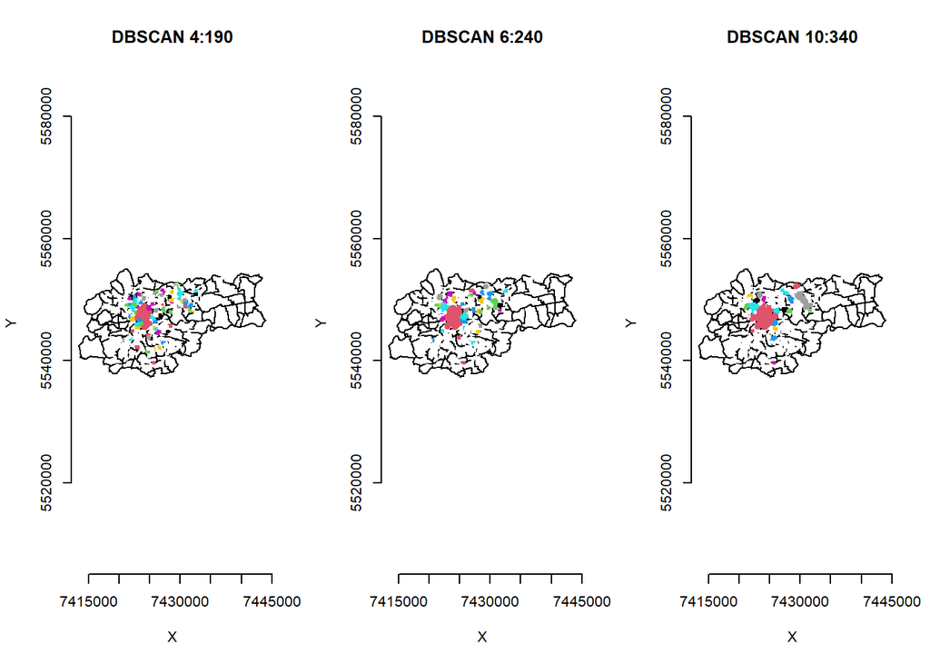

```r
par(mfrow = c(1, 3))

db <- dbscan(points_coords, eps = 190, minPts = 4)
plot(osiedle$geometry, xlab = 'X', ylab = "Y", main = "DBSCAN 4:190")
plot(points$geometry, add = TRUE, pch = 19, cex = 0.5, col = ifelse(db$cluster == 0, 0, db$cluster + 1))
axis(1)
axis(2)

db <- dbscan(points_coords, eps = 240, minPts = 6)
plot(osiedle$geometry, xlab = 'X', ylab = "Y", main = "DBSCAN 6:240")
plot(points$geometry, add = TRUE, pch = 19, cex = 0.5, col = ifelse(db$cluster == 0, 0, db$cluster + 1))
axis(1)
axis(2)
db <- dbscan(points_coords, eps = 340, minPts = 10)
plot(osiedle$geometry, xlab = 'X', ylab = "Y", main = "DBSCAN 10:340")
plot(points$geometry, add = TRUE, pch = 19, cex = 0.5, col = ifelse(db$cluster == 0, 0, db$cluster + 1))
axis(1)
axis(2)
```

```r
par(mfrow = c(1, 1))
```

W przeciwieństwie do DBSCAN, który jest algorytmem jednowarstwowym, HDBSCAN rozszerza go poprzez dodanie struktury hierarchicznej do grupowania. Tworzy hierarchię klastrów, umożliwiając analizowanie struktur o różnych poziomach gęstości. HDBSCAN podobnie jak DBSCAN posiada parametr epsilon odpowiadający odległości między puntkowej. Jest on jednak zmienny, gdyż algorytm na jego podstawie określa poziom gęstości i trwałość klastra. By zobaczyć ilość klastrów dla danego epsilon przy podanym parametrze minPts należy wykonać wizualiacje funkcji hdbscan

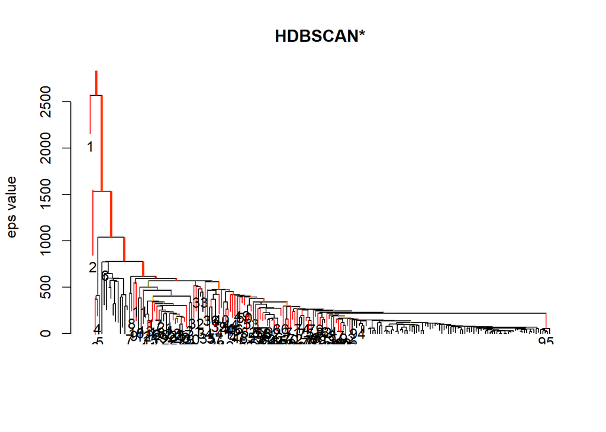

```r
hdb <- hdbscan(points_coords, minPts = 4)
plot(hdb, show_flat = TRUE)
```

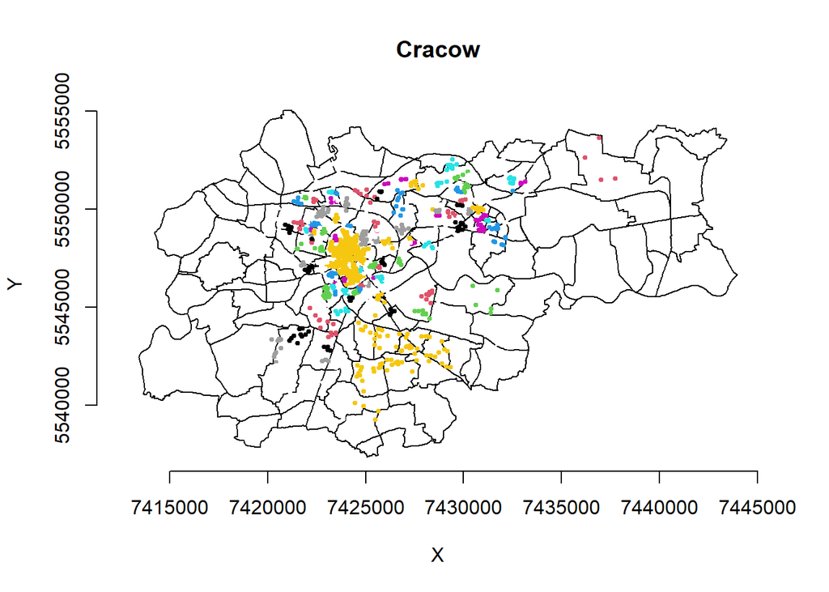

```r
plot(osiedle$geometry, xlab='X', ylab="Y")
plot(points$geometry, add=TRUE, pch=19, cex=0.5, col=ifelse(hdb$cluster == 0, 0, hdb$cluster+1))
title("Cracow")
axis(1)
axis(2)
```

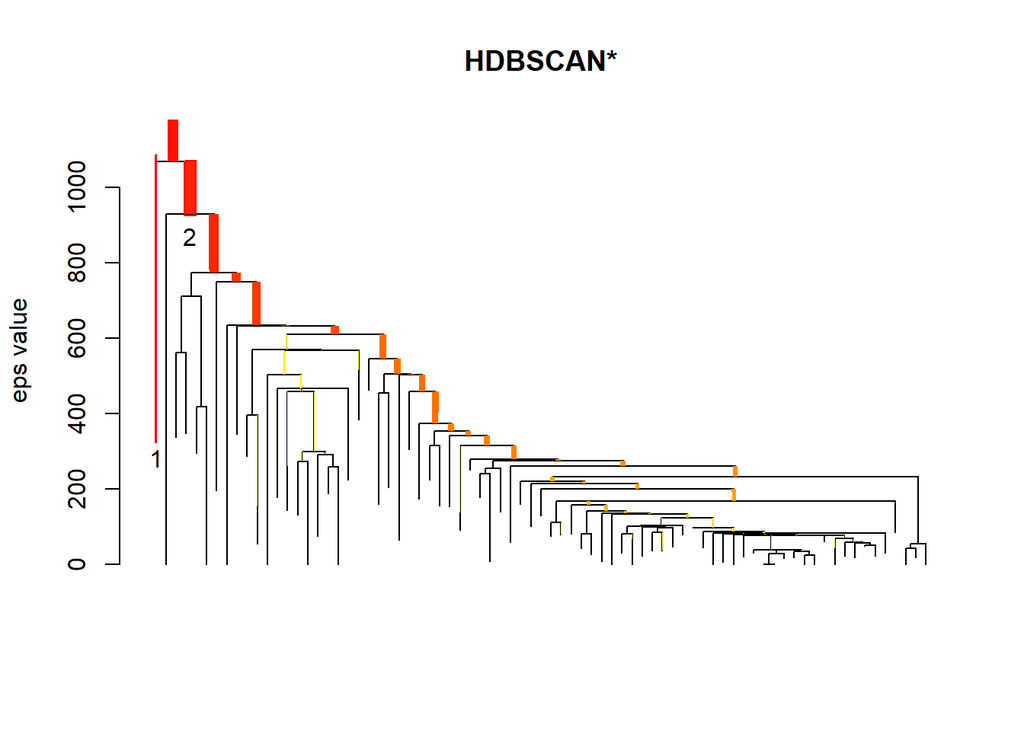

```r
hdb <- hdbscan(points_coords, minPts = 8)
plot(hdb, show_flat = TRUE)
```

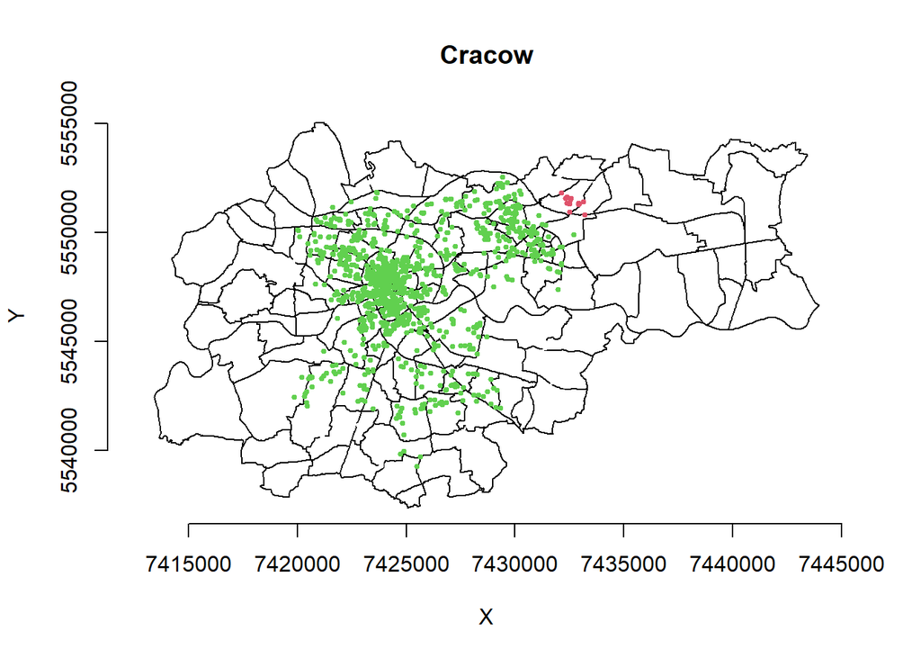

```r
plot(osiedle$geometry, xlab='X', ylab="Y")
plot(points$geometry, add=TRUE, pch=19, cex=0.5, col=ifelse(hdb$cluster == 0, 0, hdb$cluster+1))
title("Cracow")
axis(1)
axis(2)
```

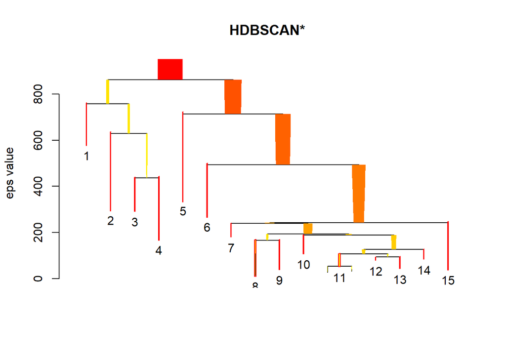

```r
hdb <- hdbscan(points_coords, minPts = 20)
plot(hdb, show_flat = TRUE)
```

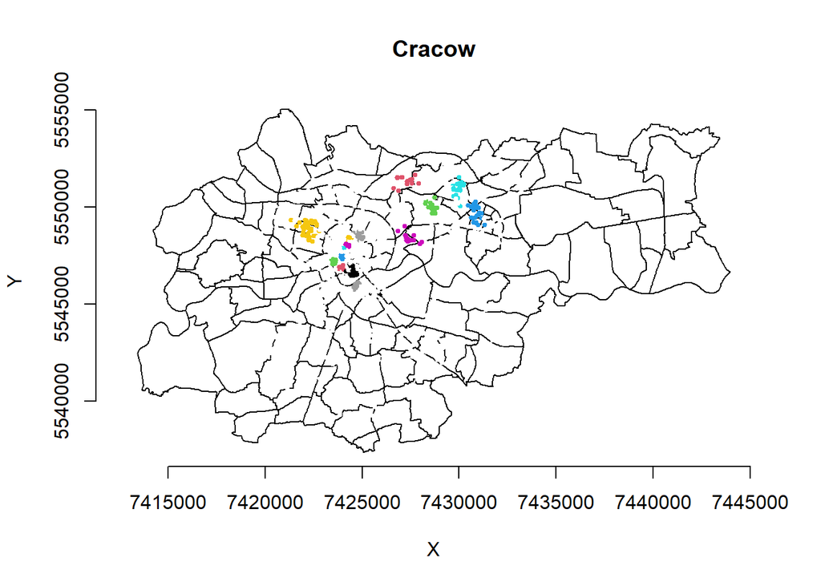

```r
plot(osiedle$geometry, xlab='X', ylab="Y")
plot(points$geometry, add=TRUE, pch=19, cex=0.5, col=ifelse(hdb$cluster == 0, 0, hdb$cluster+1))
title("Cracow")
axis(1)
axis(2)
```

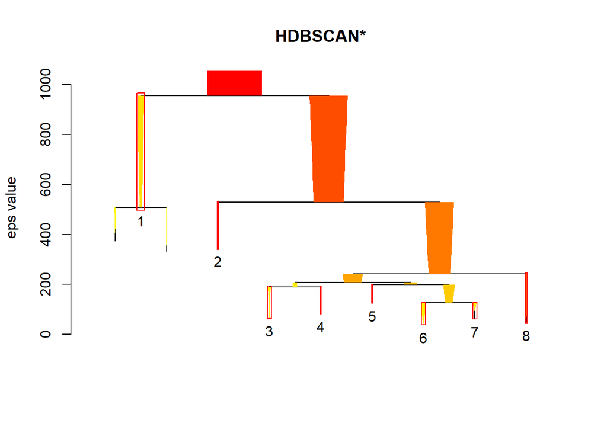

```r
hdb <- hdbscan(points_coords, minPts = 25)
plot(hdb, show_flat = TRUE)
```

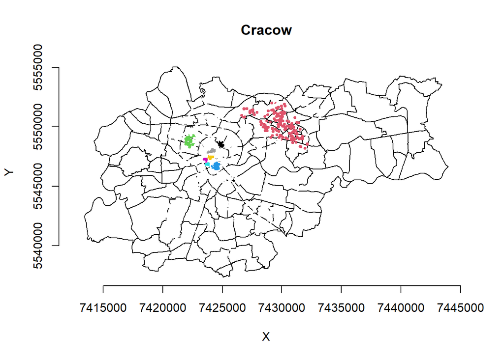

```r
plot(osiedle$geometry, xlab='X', ylab="Y")
plot(points$geometry, add=TRUE, pch=19, cex=0.5, col=ifelse(hdb$cluster == 0, 0, hdb$cluster+1))
title("Cracow")
axis(1)
axis(2)
```

Jak możemy zauważyć program podczas hierarchizacji klastrów HDBSCAN dokonuje wyboru najbardziej stabilnych i największej gęstości i traktuje je jako rozwiązanie. To daje zadziwiające wyniki, gdzie przy minPts = 8 mamy tylko 2 stabilne klastry według klasyfikacji HDBSCAN`a, za to przy minPt = 25 jest ich juz 8, gdzie można było się spodziewać, że na logikę przy mniejszej ilości punktów wymaganych będzie więcej klastrów.

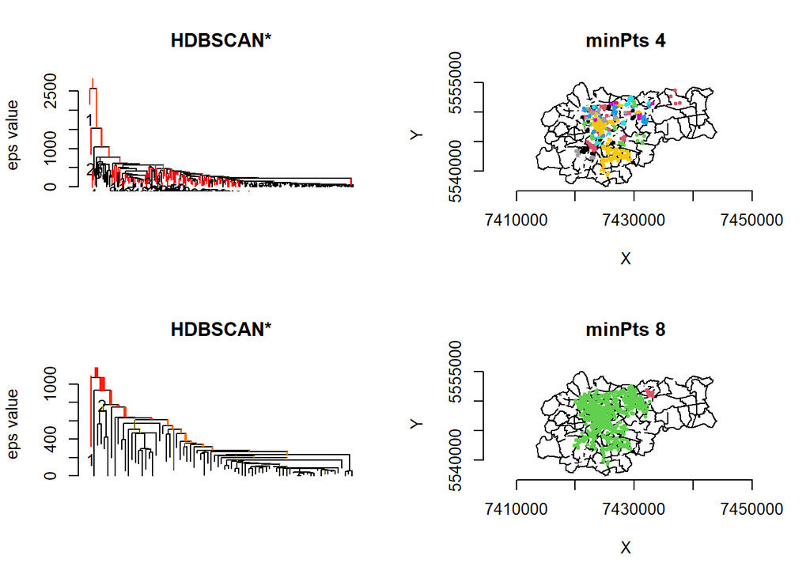

```r
par(mfrow=c(2,2))
hdb <- hdbscan(points_coords, minPts = 4)
plot(hdb, show_flat = TRUE)


plot(osiedle$geometry, xlab='X', ylab="Y")
plot(points$geometry, add=TRUE, pch=19, cex=0.5, col=ifelse(hdb$cluster == 0, 0, hdb$cluster+1))
title("minPts 4")
axis(1)
axis(2)

hdb <- hdbscan(points_coords, minPts = 8)
plot(hdb, show_flat = TRUE)


plot(osiedle$geometry, xlab='X', ylab="Y")
plot(points$geometry, add=TRUE, pch=19, cex=0.5, col=ifelse(hdb$cluster == 0, 0, hdb$cluster+1))
title("minPts 8")
axis(1)
axis(2)
```

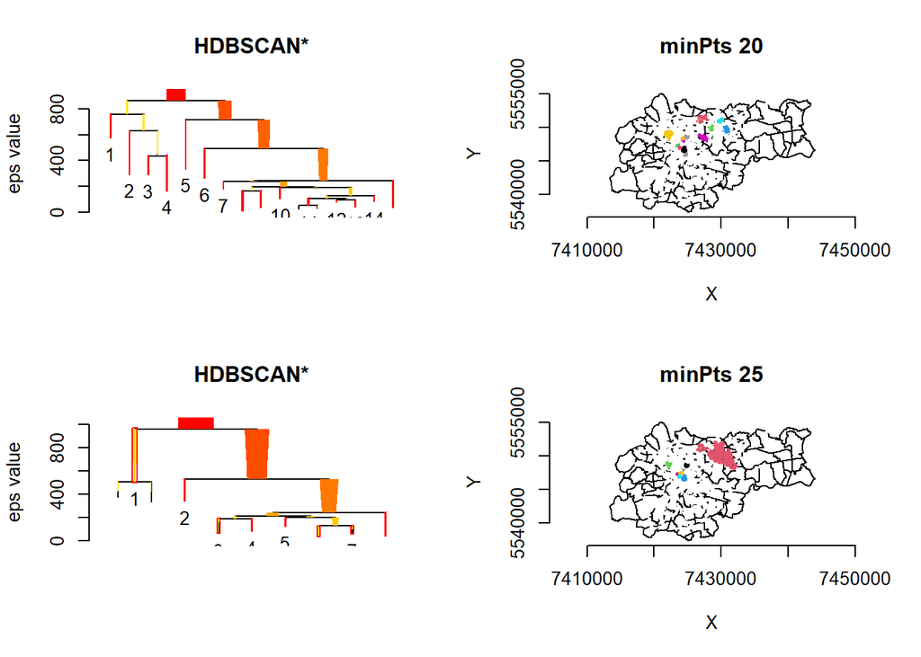

```r
par(mfrow=c(2,2))

hdb <- hdbscan(points_coords, minPts = 20)
plot(hdb, show_flat = TRUE)


plot(osiedle$geometry, xlab='X', ylab="Y")
plot(points$geometry, add=TRUE, pch=19, cex=0.5, col=ifelse(hdb$cluster == 0, 0, hdb$cluster+1))
title("minPts 20")
axis(1)
axis(2)

hdb <- hdbscan(points_coords, minPts = 25)
plot(hdb, show_flat = TRUE)


plot(osiedle$geometry, xlab='X', ylab="Y")
plot(points$geometry, add=TRUE, pch=19, cex=0.5, col=ifelse(hdb$cluster == 0, 0, hdb$cluster+1))
title("minPts 25")
axis(1)
axis(2)
```

```r
par(mfrow=c(1,1))
```

PODSUMOWANIE: Pomimo różnić w działaniu obu algorytmów, wyniki klasteryzacji są zbliżone, tzn. klastry wykrywane są mniej więcej w zbliżonych miejscach. Najczęściej klastry powstawały w okolicach Starego Miasta, Grzegrzółek, Czyżynach, Bieńczycach i Nowej Hucie. DBSCAN dodatkowo znajdował klastry w okolicach Bieżanowa, Podgórza i Krowodrzy. Są one jednak w znacznym stopniu mniejsze od pozostałych, co może świadczyć o większej podatności algoryrtmu DBSCAN na szum, niż HDBSCAN.Może to też działać w drugą stronę, HDBSCAN za szum może uznać za mniej istotny, ale wciąż istniejący klaster. Dlatego w doborze algorytmu powinniśmy się kierować celem badań i jakie wyniki chceby za ich pomocą uzyskać.